# NEON forecasting challenge

rachel torres

2025-01-22

## NEON phenology data viz

[steps to code are from this webste](https://projects.ecoforecast.org/neon4cast-ci/targets.html)

Description of data:

**gcc_90** - P1D - Green chromatic coordinate is the ratio of the green digital number to the sum of the red, green, blue digital numbers from a digital camera.  
Horizon: 30 days  
Latency: ~ 2 days

**rcc_90** - P1D - Red chromatic coordinate is the ratio of the Red digital number to the sum of the red, green, blue digital numbers from a digital camera. Horizon: 30 days  
Latency: ~ 2 days

First, select a site where phenology data is available ([see table](https://projects.ecoforecast.org/neon4cast-ci/targets.html) where phenology is marked 1)

In example below I filter by ABBY (Abby Road in Oregon) and SJER (San Joaquin Experimental Range in California)

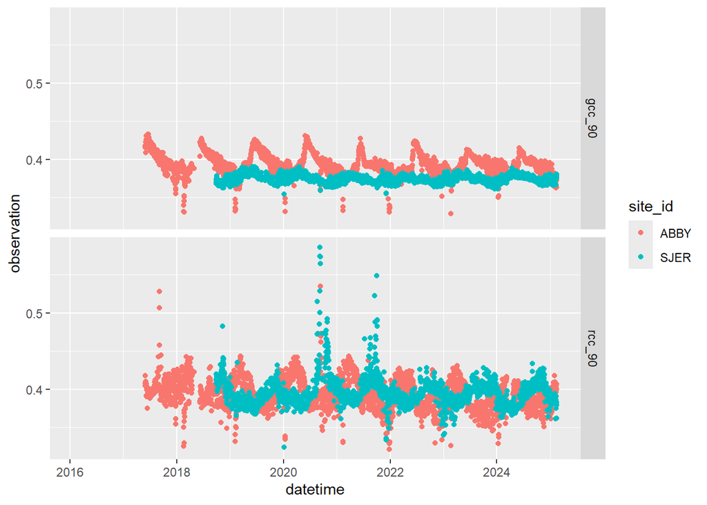

```r
#set download url
url <- "https://sdsc.osn.xsede.org/bio230014-bucket01/challenges/targets/project_id=neon4cast/duration=P1D/phenology-targets.csv.gz"

# get data frame from website
phenology_targets <- read_csv(url, show_col_types = FALSE)

# filter by site id
sites <- phenology_targets %>% filter(site_id=="ABBY" | site_id=="SJER")

# plot time series
ggplot(sites) +
  geom_point(aes(x=datetime, y=observation, col=site_id)) +
  facet_grid('variable')
```

Other ideas to explore in visualization:

- plots to make to explore - time series
- smooth time series
- monthly averages
- monthly values with year by color
- daily values by year
- average daily values

## Example Plot

[output not shown]

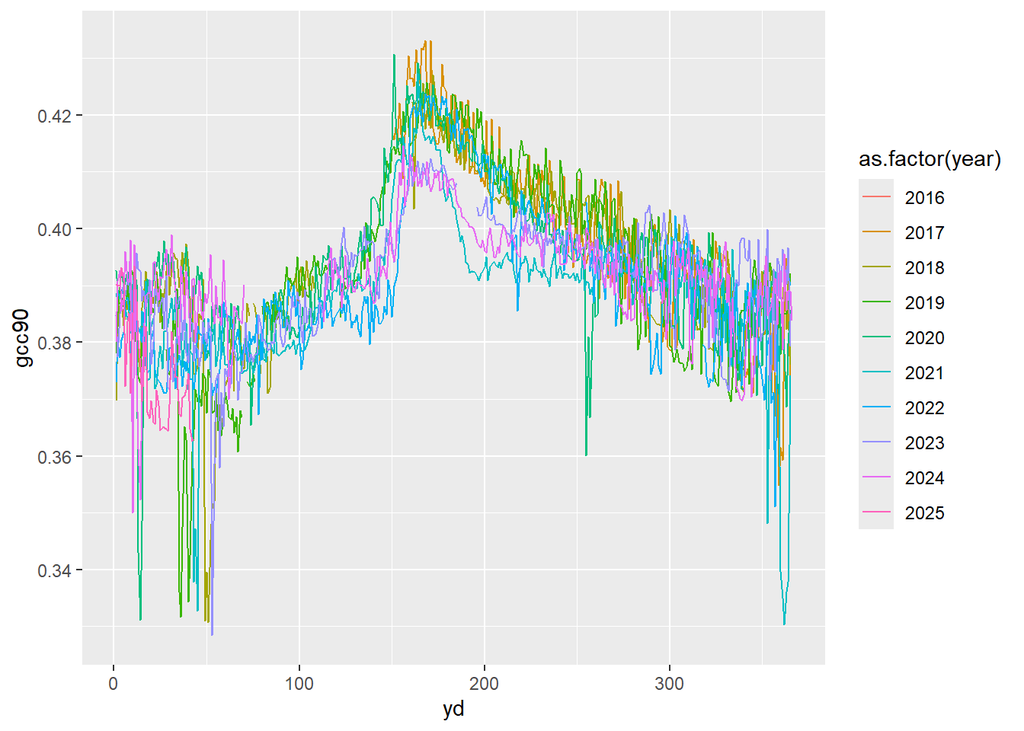

```r
# example plot that combines filter, mutating, aggregating

sites %>%
  # filter by site id
  filter(site_id=="ABBY" &
           # filter by variable - only gcc90
           variable=="gcc_90") %>%
  # use lubridate functions to get different time steps
  mutate(month = month(datetime),
         year=year(datetime),
         yd=yday(datetime)) %>%
  # summarize
  group_by(yd, year) %>%
  summarize(gcc90 = mean(observation)) %>%
  # plot
  ggplot(aes(x=yd,
             y=gcc90,
             col=as.factor(year))) +
  geom_line()
```

Continue your own code below - what patterns can you find?

## Let’s look at climate data for the NEON site

We are going to load more data using the `neonUtilities` R package - see examples [here](https://www.neonscience.org/resources/learning-hub/tutorials/neondatastackr)

We want to get air temperature values, which are available as 1 and 30 minute average from triple aspirated observations, and have an ID of DP1.00003.001.

```r
# run this first to install
#install.packages("neonUtilities")

# load package
library(neonUtilities)

# get the start and end dates for the SJER site
start = head(sites %>% filter(site_id=="SJER") %>% select(datetime))[1,]
end = tail(sites %>% filter(site_id=="SJER") %>% select(datetime))[6,]

# download the triple aspirated temperature files - for site SJER only to start - check your console, this may take a minute
triptemp <- loadByProduct(dpID="DP1.00003.001",
                          site=c("SJER"),
                          startdate=format(start$datetime, "%Y-%m"),
                          enddate=format(end$datetime, "%Y-%m"))
# the format of this download is a list of 7 that contains metadata and data frames for 1 minute observations (TAAT_1min) and 30 minute (TAAT_30min)

# get daily min, max, and mean temps
minute_daily_avg = triptemp$TAAT_1min %>%
  mutate(date = date(startDateTime)) %>%
  group_by(date) %>%
  summarize(tmin = min(tempTripleMean),
            tmax = max(tempTripleMean),
            tmean = mean(tempTripleMean)) %>%
  mutate(tmean2 = (tmin+tmax)/2)


ggplot(minute_daily_avg,
       aes(x=date, y=tmean)) +
  geom_point() +
  geom_point(aes(x=date, y=tmin, col="tmin")) +
  geom_point(aes(x=date, y=tmax, col="tmax"))

# save dataframe to computer so don't have to download again
saveRDS(minute_daily_avg, "SJER_trip_temp_NEON.Rds")
```

[output not shown]

## Get Accumulated growing degree days

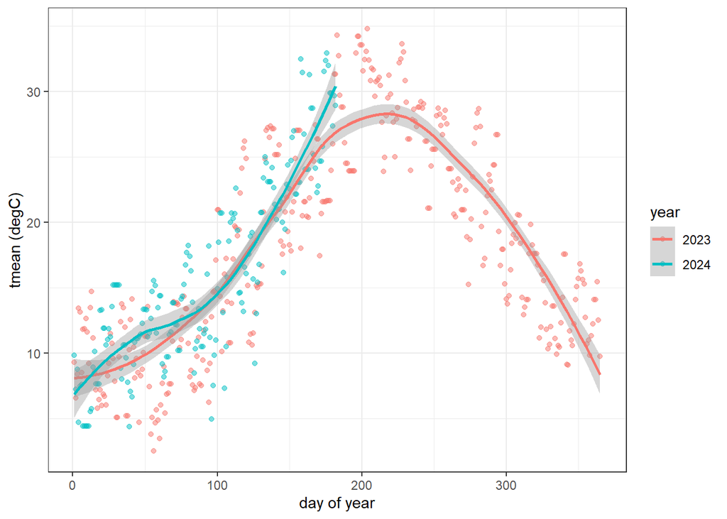

```r
minute_daily_avg <- readRDS("SJER_trip_temp_NEON.Rds")


# calculate gdd as the mean over the threshold (because we are working in celsius, the threshold is 0 or 32F, we only need the mean)

gdd = minute_daily_avg %>%
  mutate(tmean = (tmin+tmax)/2,
         year = year(date),
         doy = yday(date)) %>%
  select(year, doy, tmean) %>%
  filter(year>2022) %>%
  fill(tmean) # not the best strategy but will work for now - fills NA values with previous value

# plot as avg temperature (gdd)
ggplot(gdd, aes(x=doy, y=tmean, col=as.factor(year))) +
  geom_point(alpha=0.5) +
  geom_smooth() +
  labs(x="day of year", y="tmean (degC)", col="year") +
  theme_bw()
```

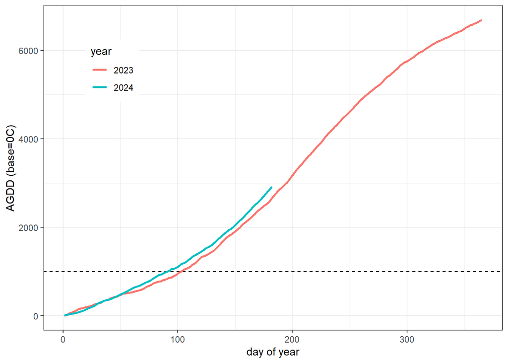

```r
# create a new column for cumulative values, starting at 0 for each year
# cumsum is a base function that takes a vector and produces a new vector with cumulative values. try putting ?cumsum into your console to learn more, or visualize an example by putting `cumsum(c(1,2,3,4))` into your console
gdd <- gdd %>%
  group_by(year) %>%
  mutate(agdd = cumsum(tmean))

# plot agdd
ggplot(gdd, aes(x=doy, y=agdd, col=as.factor(year))) +
  geom_hline(aes(yintercept=1000), linetype="dashed") +
  geom_line(linewidth=1) +
  labs(x="day of year", y="AGDD (base=0C)", col="year") +
  theme_bw() + theme(legend.position = "inside",
                     legend.position.inside = c(0.15, 0.8))
```